# NOAA Storm Analysis: Top Health and Financial Damage Events

## Data Processing

```r
#read the data
rawdata<-read.csv("repdata-data-StormData.csv.bz2")
```

Prepare the data by aggregating injuries, fatalities, property damage, and crop damage by events. Only the top 10 events are displayed in this report.

```r
#load the dplyr package for grouping and summarizing
library(dplyr)

#aggregate health issues into a data frame of the top 10 health events
healthbyEVTYPE <- rawdata %>% group_by(EVTYPE) %>% summarise(TotalInjuries = sum(INJURIES), TotalFatalities=sum(FATALITIES))
healthbyEVTYPE$Total <- healthbyEVTYPE$TotalInjuries + healthbyEVTYPE$TotalFatalities
top10healthEVTYPE<- head(healthbyEVTYPE[order(-healthbyEVTYPE$Total), ],10)
```

The property and crop data needs conversion of text multipliers into numeric before we can aggregate  
the data into top 10 financial damage events.

```r
#unique exponents used in property damage
unique(rawdata$PROPDMGEXP)
```

```
##  [1] K M   B m + 0 5 6 ? 4 2 3 h 7 H - 1 8
## Levels:  - ? + 0 1 2 3 4 5 6 7 8 B h H K m M
```

```r
#unique exponents used in crop damage
unique(rawdata$CROPDMGEXP)
```

```
## [1]   M K m B ? 0 k 2
## Levels:  ? 0 2 B k K m M
```

```r
#copy just the variables for property and crop damage
dmgdata<-data.frame(rawdata$EVTYPE,rawdata$PROPDMG,rawdata$PROPDMGEXP,rawdata$CROPDMG,rawdata$CROPDMGEXP)
names(dmgdata)<-c("EVTYPE","PROPDMG","PROPDMGEXP","CROPDMG","CROPDMGEXP")

#Replace exponent code with numeric values
dmgdata$PROPDMGEXPN[dmgdata$PROPDMGEXP=="M"] <- 1e+06
dmgdata$PROPDMGEXPN[dmgdata$PROPDMGEXP=="m"] <- 1e+06
dmgdata$PROPDMGEXPN[dmgdata$PROPDMGEXP=="K"] <- 1e+03
dmgdata$PROPDMGEXPN[dmgdata$PROPDMGEXP=="H"] <- 1e+02
dmgdata$PROPDMGEXPN[dmgdata$PROPDMGEXP=="h"] <- 1e+06
dmgdata$PROPDMGEXPN[dmgdata$PROPDMGEXP=="B"] <- 1e+09
dmgdata$PROPDMGEXPN[dmgdata$PROPDMGEXP=="8"] <- 1e+08
dmgdata$PROPDMGEXPN[dmgdata$PROPDMGEXP=="7"] <- 1e+07
dmgdata$PROPDMGEXPN[dmgdata$PROPDMGEXP=="6"] <- 1e+06
dmgdata$PROPDMGEXPN[dmgdata$PROPDMGEXP=="5"] <- 1e+05
dmgdata$PROPDMGEXPN[dmgdata$PROPDMGEXP=="4"] <- 1e+04
dmgdata$PROPDMGEXPN[dmgdata$PROPDMGEXP=="3"] <- 1e+03
dmgdata$PROPDMGEXPN[dmgdata$PROPDMGEXP=="2"] <- 1e+02
dmgdata$PROPDMGEXPN[dmgdata$PROPDMGEXP=="1"] <- 1e+01
dmgdata$PROPDMGEXPN[dmgdata$PROPDMGEXP=="0"] <- 1
dmgdata$PROPDMGEXPN[dmgdata$PROPDMGEXP==""]  <- 1
dmgdata$PROPDMGEXPN[dmgdata$PROPDMGEXP=="+"] <- 0
dmgdata$PROPDMGEXPN[dmgdata$PROPDMGEXP=="-"] <- 0
dmgdata$PROPDMGEXPN[dmgdata$PROPDMGEXP=="?"] <- 0

#multiply the base and exponent to get numerical total of property damage
dmgdata$PROPDMGN <- dmgdata$PROPDMG * dmgdata$PROPDMGEXPN
```

Crop damage

```r
#Replace exponent code with numeric values
dmgdata$CROPDMGEXPN[dmgdata$CROPDMGEXP=="M"] <- 1e+06
dmgdata$CROPDMGEXPN[dmgdata$CROPDMGEXP=="m"] <- 1e+06
dmgdata$CROPDMGEXPN[dmgdata$CROPDMGEXP=="K"] <- 1e+03
dmgdata$CROPDMGEXPN[dmgdata$CROPDMGEXP=="k"] <- 1e+03
dmgdata$CROPDMGEXPN[dmgdata$CROPDMGEXP=="B"] <- 1e+09
dmgdata$CROPDMGEXPN[dmgdata$CROPDMGEXP=="2"] <- 1e+02
dmgdata$PROPDMGEXPN[dmgdata$PROPDMGEXP==""]  <- 1
dmgdata$CROPDMGEXPN[dmgdata$CROPDMGEXP=="0"] <- 1
dmgdata$CROPDMGEXPN[dmgdata$CROPDMGEXP=="?"] <- 0

#Multiply the base and exponent to get numerical total of crop damage
dmgdata$CROPDMGN <- dmgdata$CROPDMG * dmgdata$CROPDMGEXPN
```

Aggregate damage into top 10 events

```r
dmgbyEVTYPE <- dmgdata %>% group_by(EVTYPE) %>% summarise(TotalPropDmg = sum(PROPDMGN), TotalCropDmg=sum(CROPDMGN))
dmgbyEVTYPE$Total <- dmgbyEVTYPE$TotalPropDmg + dmgbyEVTYPE$TotalCropDmg
top10dmgbyEVTYPE<- head(dmgbyEVTYPE[order(-dmgbyEVTYPE$Total), ],10)
```

## Results

#### Question 1. Across the United States, which types of events are most harmful with respect to population health?

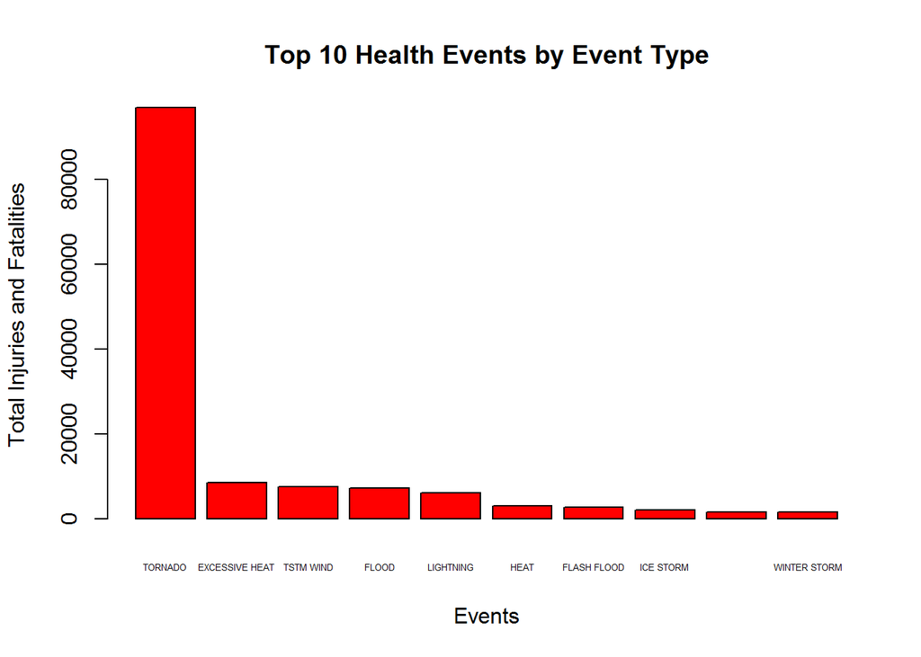

```r
#Plot the top 10 health events.
barplot(top10healthEVTYPE$Total,
        main = "Top 10 Health Events by Event Type",
        xlab= "Events",
        ylab= "Total Injuries and Fatalities",
                names.arg = top10healthEVTYPE$EVTYPE, cex.names = .4, col="red")
```

Figure 1. This plot compares the total reported injuries plus fatalities by event type.

```r
#Data for the plot in Figure 1 above.
top10healthEVTYPE
```

```
## Source: local data frame [10 x 4]
##
##               EVTYPE TotalInjuries TotalFatalities Total
##               (fctr)         (dbl)           (dbl) (dbl)
## 1            TORNADO         91346            5633 96979
## 2     EXCESSIVE HEAT          6525            1903  8428
## 3          TSTM WIND          6957             504  7461
## 4              FLOOD          6789             470  7259
## 5          LIGHTNING          5230             816  6046
## 6               HEAT          2100             937  3037
## 7        FLASH FLOOD          1777             978  2755
## 8          ICE STORM          1975              89  2064
## 9  THUNDERSTORM WIND          1488             133  1621
## 10      WINTER STORM          1321             206  1527
```

From the data above, Tornados are by far the leading cause of injury and fatalities across the United States.

#### Question 2. Across the United States, which types of events have the greatest economic consequences?

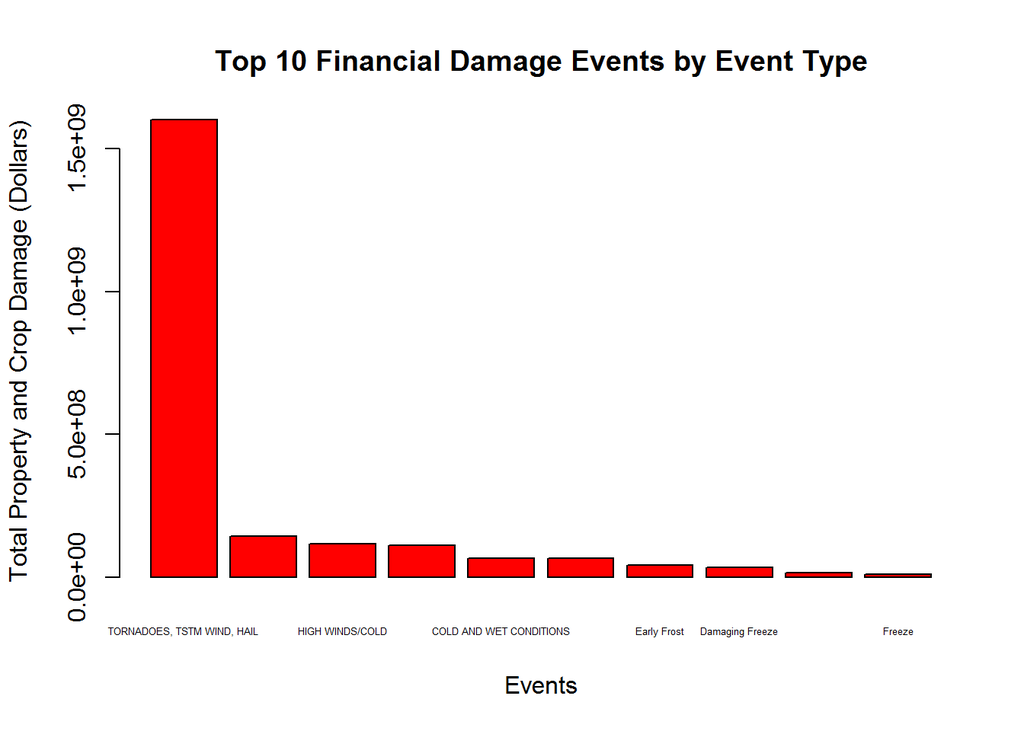

```r
#Plot the top 10 financial damage events.
barplot(top10dmgbyEVTYPE$Total,
        main ="Top 10 Financial Damage Events by Event Type",
        xlab = "Events",
        ylab = "Total Property and Crop Damage (Dollars)",
        names.arg = top10dmgbyEVTYPE$EVTYPE,
        cex.names = .4,
        col="red")
```

Figure 2. This plot compares the total reported property damage plus crop damage in dollars by event type.

```r
#Data for plot in Figure 2 above.
top10dmgbyEVTYPE
```

```
## Source: local data frame [10 x 4]
##
##                        EVTYPE TotalPropDmg TotalCropDmg      Total
##                        (fctr)        (dbl)        (dbl)      (dbl)
## 1  TORNADOES, TSTM WIND, HAIL    1.600e+09      2500000 1602500000
## 2           EXCESSIVE WETNESS    0.000e+00    142000000  142000000
## 3             HIGH WINDS/COLD    1.105e+08      7000000  117500000
## 4   HURRICANE OPAL/HIGH WINDS    1.000e+08     10000000  110000000
## 5     COLD AND WET CONDITIONS    0.000e+00     66000000   66000000
## 6     WINTER STORM HIGH WINDS    6.000e+07      5000000   65000000
## 7                 Early Frost    0.000e+00     42000000   42000000
## 8             Damaging Freeze    0.000e+00     34130000   34130000
## 9        Heavy Rain/High Surf    1.350e+07      1500000   15000000
## 10                     Freeze    0.000e+00     10500000   10500000
```